# Red Wines of Portugal

Rick Rice

12/17/2019

## The Data - Wine Quality data set

The data comes from the University of California at Irvine, Machine Learning Repository.

They request the inclusion of this citation -

P. Cortez, A. Cerdeira, F. Almeida, T. Matos and J. Reis. Modeling wine preferences by data mining from physicochemical properties. In Decision Support Systems, Elsevier, 47(4):547-553, 2009.

Based on physiochemical tests, input records contain the following variables:

1. fixed acidity
2. volatile acidity
3. citric acid
4. residual sugar
5. chlorides
6. free sulfur dioxide
7. total sulfur dioxide
8. density
9. pH
10. sulphates
11. alcohol
12. quality (integer between 0 and 10 - output variable based on sensory data)

First eleven variables are numeric, twelth is an integer.

## Data Input

Portugal red wine data is read in. There are 1599 rows of data and no missing values.

```r
library("tidyverse")
setwd("F:/DATA 101/Final Project")

wine_df = read.csv("winequality-red.csv",header=TRUE,sep=";")

head(wine_df,4)
```

```
##   fixed.acidity volatile.acidity citric.acid residual.sugar chlorides
## 1           7.4             0.70        0.00            1.9     0.076
## 2           7.8             0.88        0.00            2.6     0.098
## 3           7.8             0.76        0.04            2.3     0.092
## 4          11.2             0.28        0.56            1.9     0.075
##   free.sulfur.dioxide total.sulfur.dioxide density   pH sulphates alcohol
## 1                  11                   34  0.9978 3.51      0.56     9.4
## 2                  25                   67  0.9968 3.20      0.68     9.8
## 3                  15                   54  0.9970 3.26      0.65     9.8
## 4                  17                   60  0.9980 3.16      0.58     9.8
##   quality
## 1       5
## 2       5
## 3       5
## 4       6
```

```r
dim(wine_df)
```

```
## [1] 1599   12
```

```r
summary(wine_df)
```

```
##  fixed.acidity   volatile.acidity  citric.acid    residual.sugar
##  Min.   : 4.60   Min.   :0.1200   Min.   :0.000   Min.   : 0.900
##  1st Qu.: 7.10   1st Qu.:0.3900   1st Qu.:0.090   1st Qu.: 1.900
##  Median : 7.90   Median :0.5200   Median :0.260   Median : 2.200
##  Mean   : 8.32   Mean   :0.5278   Mean   :0.271   Mean   : 2.539
##  3rd Qu.: 9.20   3rd Qu.:0.6400   3rd Qu.:0.420   3rd Qu.: 2.600
##  Max.   :15.90   Max.   :1.5800   Max.   :1.000   Max.   :15.500
##    chlorides       free.sulfur.dioxide total.sulfur.dioxide    density
##  Min.   :0.01200   Min.   : 1.00       Min.   :  6.00       Min.   :0.9901
##  1st Qu.:0.07000   1st Qu.: 7.00       1st Qu.: 22.00       1st Qu.:0.9956
##  Median :0.07900   Median :14.00       Median : 38.00       Median :0.9968
##  Mean   :0.08747   Mean   :15.87       Mean   : 46.47       Mean   :0.9967
##  3rd Qu.:0.09000   3rd Qu.:21.00       3rd Qu.: 62.00       3rd Qu.:0.9978
##  Max.   :0.61100   Max.   :72.00       Max.   :289.00       Max.   :1.0037
##        pH          sulphates         alcohol         quality
##  Min.   :2.740   Min.   :0.3300   Min.   : 8.40   Min.   :3.000
##  1st Qu.:3.210   1st Qu.:0.5500   1st Qu.: 9.50   1st Qu.:5.000
##  Median :3.310   Median :0.6200   Median :10.20   Median :6.000
##  Mean   :3.311   Mean   :0.6581   Mean   :10.42   Mean   :5.636
##  3rd Qu.:3.400   3rd Qu.:0.7300   3rd Qu.:11.10   3rd Qu.:6.000
##  Max.   :4.010   Max.   :2.0000   Max.   :14.90   Max.   :8.000
```

```r
sum(is.na(wine_df$fixed.acidity))
```

```
## [1] 0
```

```r
sum(is.na(wine_df$volatile.acidity))
```

```
## [1] 0
```

```r
sum(is.na(wine_df$citric.acid))
```

```
## [1] 0
```

```r
sum(is.na(wine_df$residual.sugar))
```

```
## [1] 0
```

```r
sum(is.na(wine_df$chlorides))
```

```
## [1] 0
```

```r
sum(is.na(wine_df$free.sulfur.dioxide))
```

```
## [1] 0
```

```r
sum(is.na(wine_df$total.sulfur.dioxide))
```

```
## [1] 0
```

```r
sum(is.na(wine_df$density))
```

```
## [1] 0
```

```r
sum(is.na(wine_df$pH))
```

```
## [1] 0
```

```r
sum(is.na(wine_df$sulfates))
```

```
## [1] 0
```

```r
sum(is.na(wine_df$alhocol))
```

```
## [1] 0
```

```r
sum(is.na(wine_df$quality))
```

```
## [1] 0
```

## Question One - How are the quality indicators distributed?

```r
red = c(0,0,0,0,0,0,0,0,0,0)
red[1] = sum((wine_df$quality==1))
red[2] = sum((wine_df$quality==2))
red[3] = sum((wine_df$quality==3))
red[4] = sum((wine_df$quality==4))
red[5] = sum((wine_df$quality==5))
red[6] = sum((wine_df$quality==6))
red[7] = sum((wine_df$quality==7))
red[8] = sum((wine_df$quality==8))
red[9] = sum((wine_df$quality==9))
red[10] = sum((wine_df$quality==10))
red
```

```
##  [1]   0   0  10  53 681 638 199  18   0   0
```

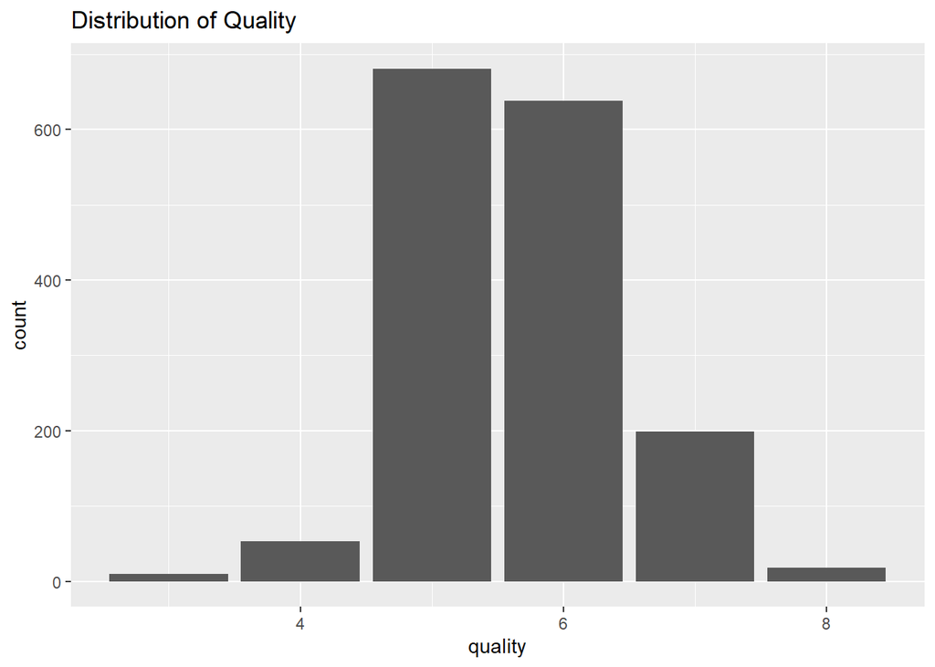

```r
ggplot(data=wine_df) +
  geom_bar(mapping=aes(x=quality)) +
  labs(title="Distribution of Quality")
```

## Question Two - In what attributes do the poor and excellent quality wines differ?

Wines with quality greater than six are deemed excellent. Those with quality less than six are deemed poor. Quality six wines are left as a kind of buffer zone to ensure contrast between the poor and the excellent.

The test dataframe for EDA contains poor wine records with a “poor” indicator and excellent wine records with an “excellent” indicator. For this section only, test data will include each excellent record three times because there are about three times as many poor as excellent wines. This allows for more meaningful graphs.

Dodge position histograms are plotted for all eleven physiochemical measures.

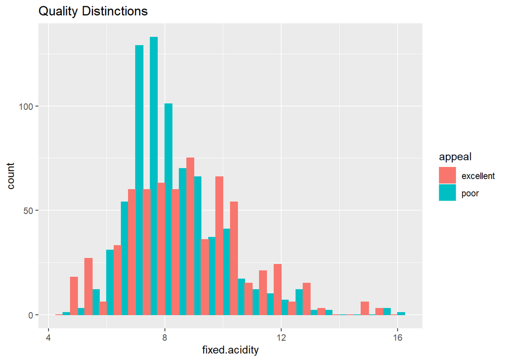

```r
good_df = mutate(filter(wine_df,quality > 6),appeal="excellent")
poor_df = mutate(filter(wine_df,quality < 6),appeal="poor")

test_df = rbind(good_df,good_df,good_df,poor_df)

ggplot(test_df,aes(x=fixed.acidity,color=appeal,fill=appeal)) +
  geom_histogram(position="dodge",binwidth=0.5) +
  labs(title="Quality Distinctions")
```

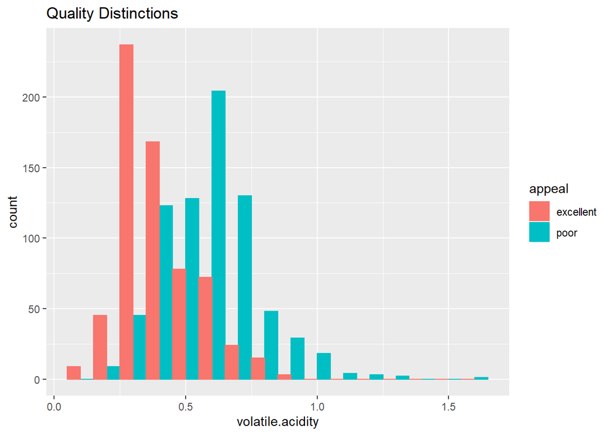

```r
ggplot(test_df,aes(x=volatile.acidity,color=appeal,fill=appeal)) +
  geom_histogram(position="dodge",binwidth=0.1) +
  labs(title="Quality Distinctions")
```

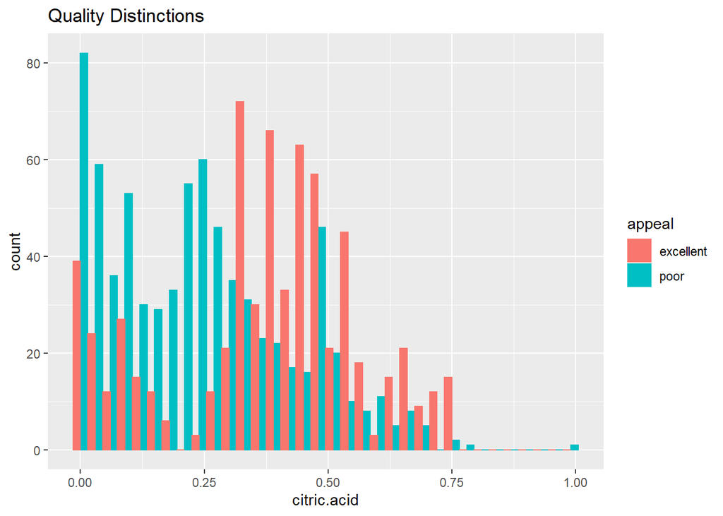

```r
ggplot(test_df,aes(x=citric.acid,color=appeal,fill=appeal)) +
  geom_histogram(position="dodge",binwidth=.03) +
  labs(title="Quality Distinctions")
```

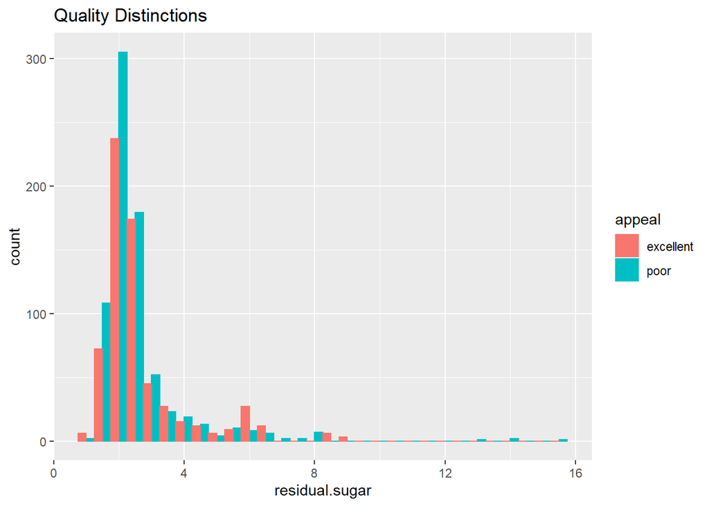

```r
ggplot(test_df,aes(x=residual.sugar,color=appeal,fill=appeal)) +
  geom_histogram(position="dodge",binwidth=0.5) +
  labs(title="Quality Distinctions")
```

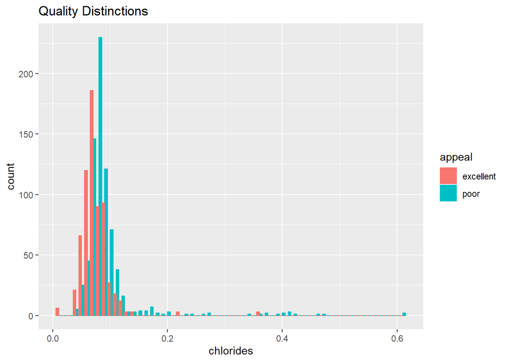

```r
ggplot(test_df,aes(x=chlorides,color=appeal,fill=appeal)) +
  geom_histogram(position="dodge",binwidth=0.01) +
  labs(title="Quality Distinctions")
```

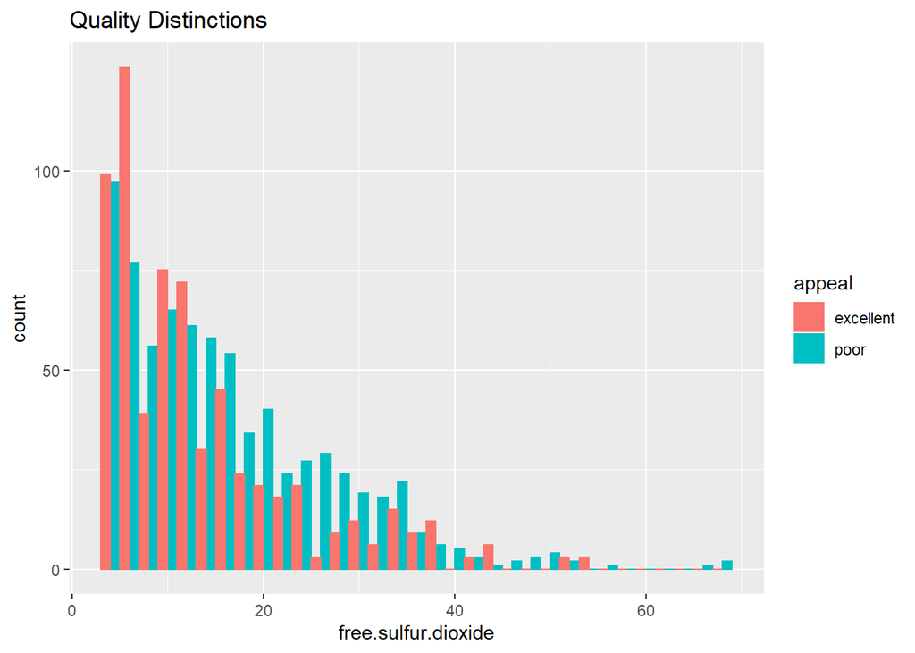

```r
ggplot(test_df,aes(x=free.sulfur.dioxide,color=appeal,fill=appeal)) +
  geom_histogram(position="dodge",binwidth=2.0) +
  labs(title="Quality Distinctions")
```

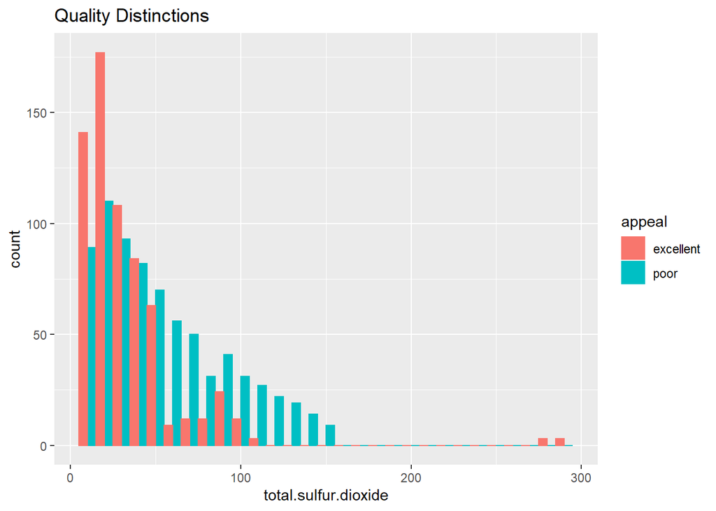

```r
ggplot(test_df,aes(x=total.sulfur.dioxide,color=appeal,fill=appeal)) +
  geom_histogram(position="dodge",binwidth=10) +
  labs(title="Quality Distinctions")
```

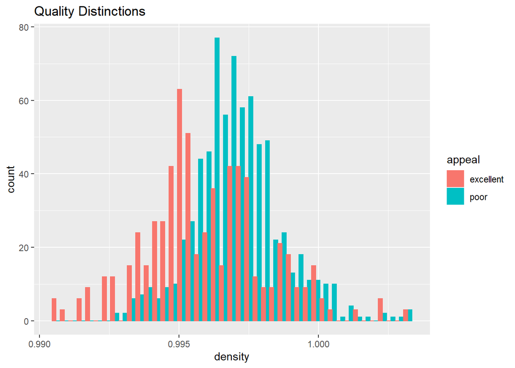

```r
ggplot(test_df,aes(x=density,color=appeal,fill=appeal)) +
  geom_histogram(position="dodge",binwidth=0.0003) +
  labs(title="Quality Distinctions")
```

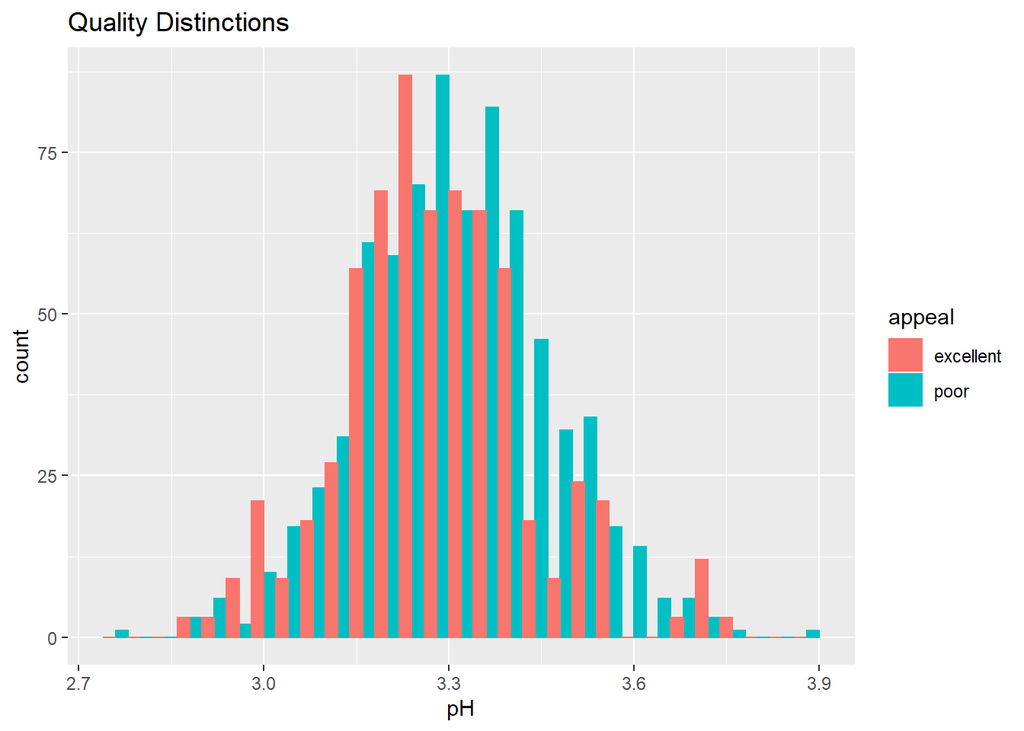

```r
ggplot(test_df,aes(x=pH,color=appeal,fill=appeal)) +
  geom_histogram(position="dodge",binwidth=0.04) +
  labs(title="Quality Distinctions")
```

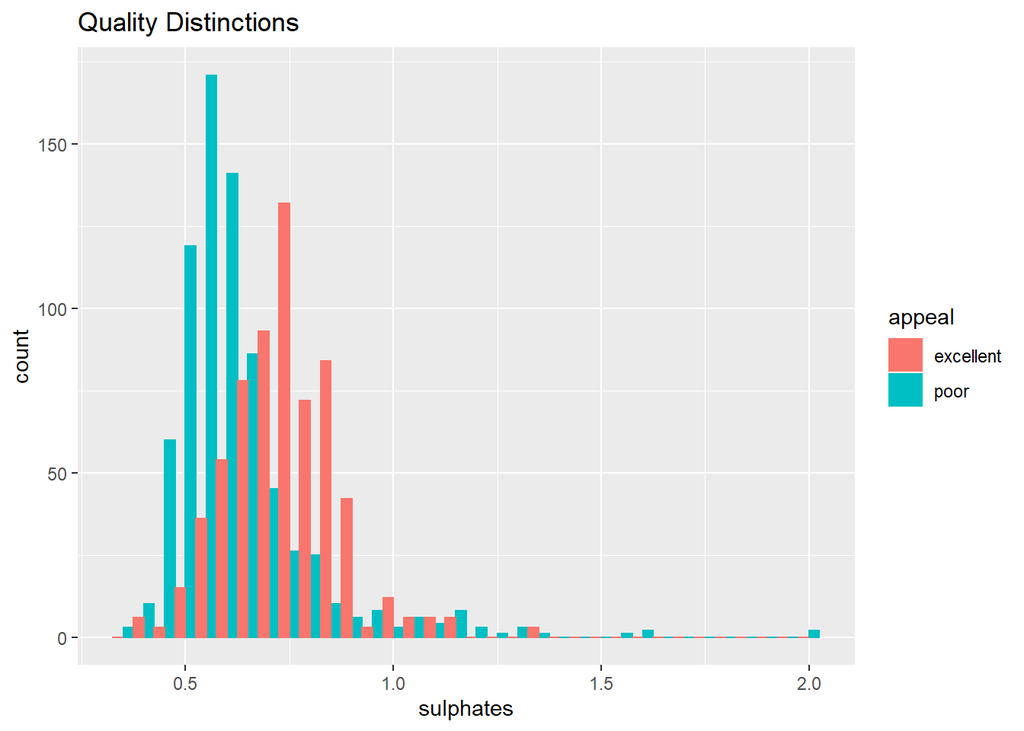

```r
ggplot(test_df,aes(x=sulphates,color=appeal,fill=appeal)) +
  geom_histogram(position="dodge",binwidth=.05) +
  labs(title="Quality Distinctions") +
  labs(title="Quality Distinctions")
```

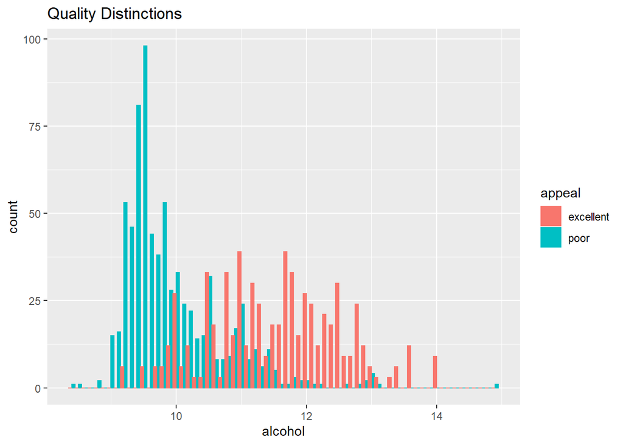

```r
ggplot(test_df,aes(x=alcohol,color=appeal,fill=appeal)) +
  geom_histogram(position="dodge",binwidth=.1) +
  labs(title="Quality Distinctions")
```

For five measures which seem to show the greatest difference between poor and excellent wines, box plots are created.

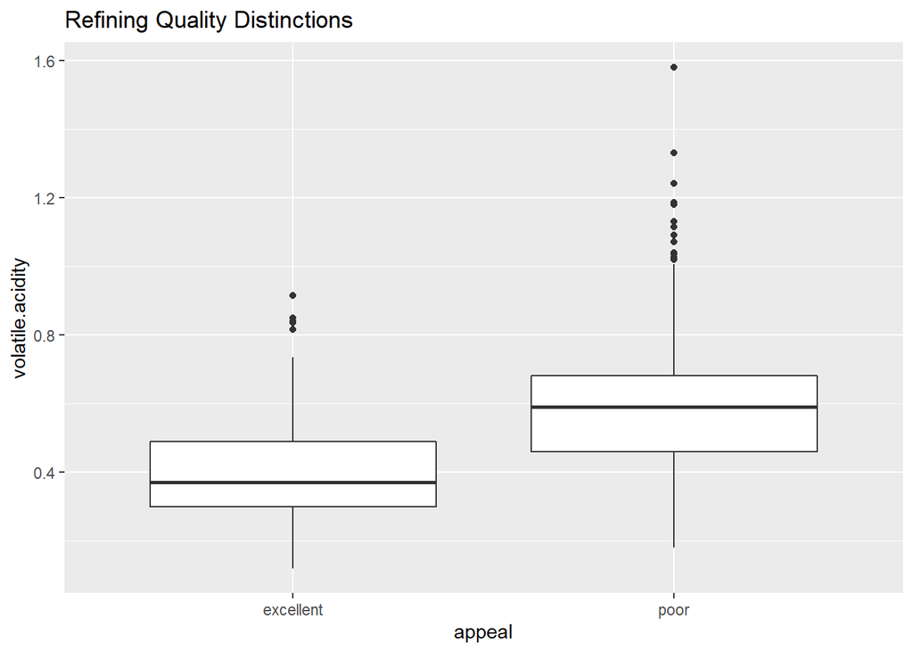

```r
ggplot(data=test_df, mapping=aes(x=appeal, y=volatile.acidity)) +
  geom_boxplot() +
  labs(title="Refining Quality Distinctions")
```

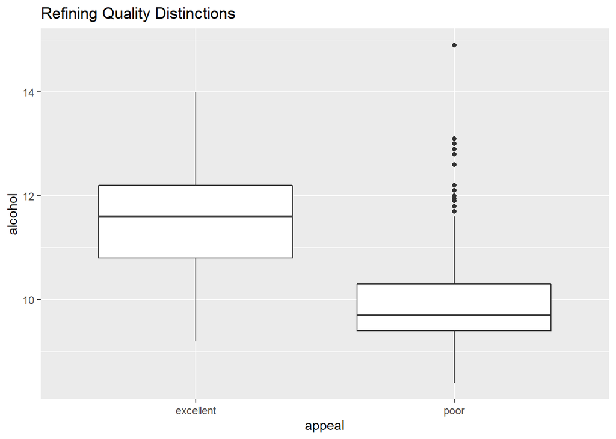

```r
ggplot(data=test_df, mapping=aes(x=appeal, y=alcohol)) +
  geom_boxplot() +
  labs(title="Refining Quality Distinctions")
```

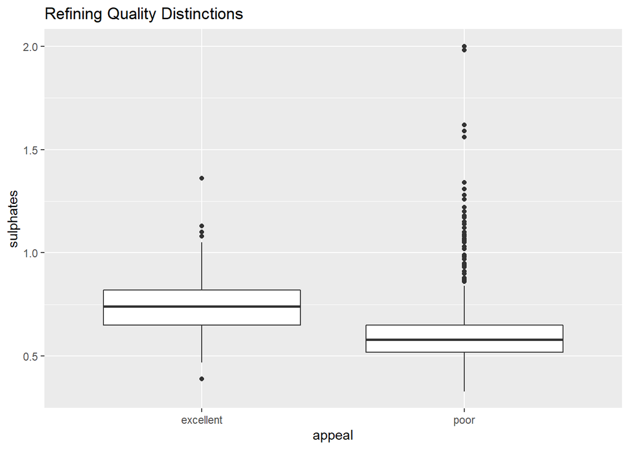

```r
ggplot(data=test_df, mapping=aes(x=appeal, y=sulphates)) +
  geom_boxplot() +
  labs(title="Refining Quality Distinctions")
```

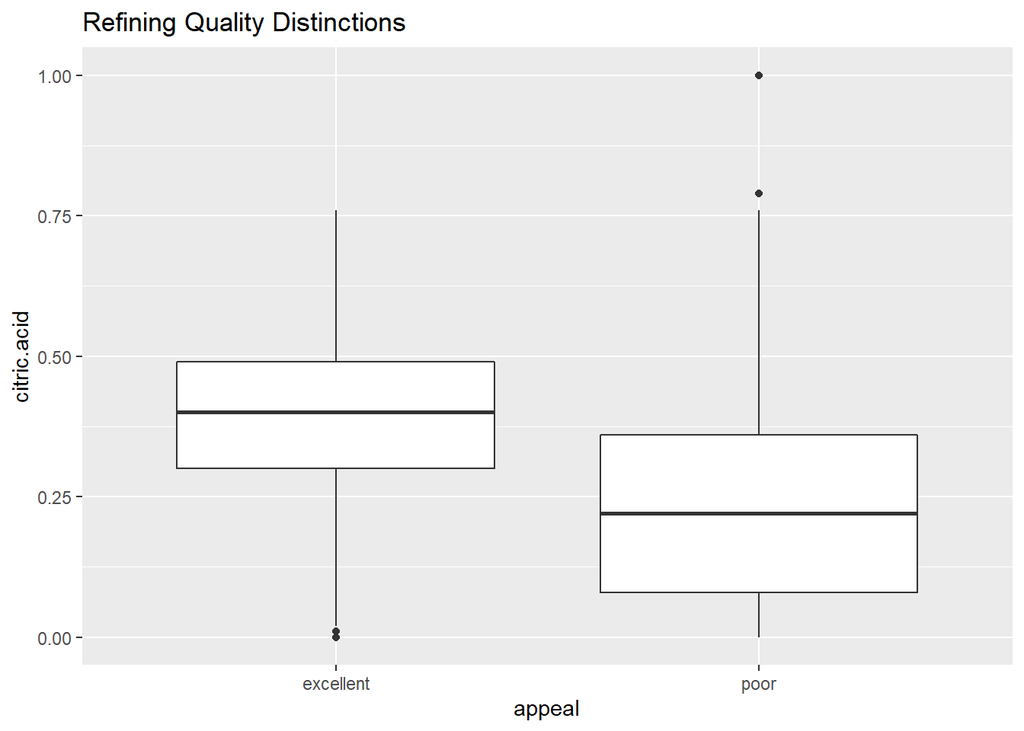

```r
ggplot(data=test_df, mapping=aes(x=appeal, y=citric.acid)) +
  geom_boxplot() +
  labs(title="Refining Quality Distinctions")
```

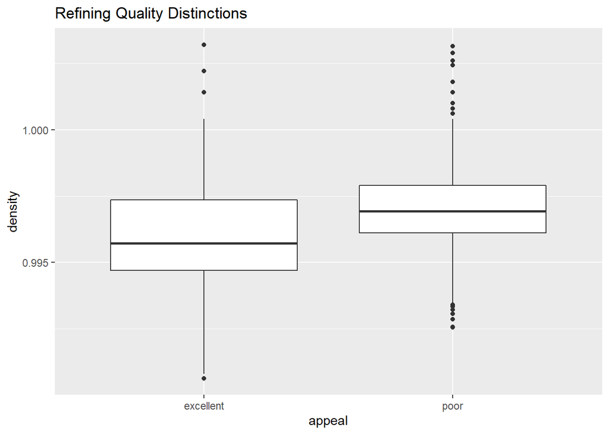

```r
ggplot(data=test_df, mapping=aes(x=appeal, y=density)) +
  geom_boxplot() +
  labs(title="Refining Quality Distinctions")
```

## EDA Summary

Quality ratings, while theoretically ranging from one to ten were limited to a low of three and a high of eight in our data. Most scores were five or six. The distridution of quality grades roughly seemed to follow a normal distribution with small tails, except for the fact that the data was discrete, limited to integers, rather than continuous.

Between the poor and excellent wines, the main differences appeared to be in volatile acidity, alcohol, sulphates, citric acid and density. More was better except in the case of volatile acidity and density which appeared to be be negatively correlated to quality.

## Question Three and the two sample t-test

Are the differences between the excellent wines and poor wine statistically significant with reguards to differences in volatile acidity, alcohol, sulphates, citric acid and density?

Spoiler alert: Accoring to the t-test, yes, they are statistically different!

Assumptions: To the best of our knowledge our samples are random and independent. They are represented as such. In charts above the values tend to distribute with a normal appearance, but our sample size is well over thirty.

H<sub>o</sub>: The characteristics of the poor and excellent wines are the same. H<sub>A</sub>: For each of the five measures chosen, there is a real difference in the ammount (of volatile acidity, sulphates, alcohol, density, citric acid) between the excellent and poor wines. Five separate t-tests performed.

```r
#  The excellent vs the poor wines are t-tested with repect to the five
#  attributes in which they appear to vary the most.  Differences are
#  significant at the .05 level (and well below) between the two groups of
#  wine, with respect to all five variables.
#
test_df = rbind(good_df,poor_df)

t.test(test_df$volatile.acidity ~ test_df$appeal)
```

```
##
##  Welch Two Sample t-test
##
## data:  test_df$volatile.acidity by test_df$appeal
## t = -15.582, df = 423.81, p-value < 2.2e-16
## alternative hypothesis: true difference in means is not equal to 0
## 95 percent confidence interval:
##  -0.2071803 -0.1607652
## sample estimates:
## mean in group excellent      mean in group poor
##               0.4055300               0.5895027
```

```r
t.test(test_df$sulphates ~ test_df$appeal)
```

```
##
##  Welch Two Sample t-test
##
## data:  test_df$sulphates by test_df$appeal
## t = 11.195, df = 454.99, p-value < 2.2e-16
## alternative hypothesis: true difference in means is not equal to 0
## 95 percent confidence interval:
##  0.1029920 0.1468506
## sample estimates:
## mean in group excellent      mean in group poor
##               0.7434562               0.6185349
```

```r
t.test(test_df$alcohol ~ test_df$appeal)
```

```
##
##  Welch Two Sample t-test
##
## data:  test_df$alcohol by test_df$appeal
## t = 21.732, df = 292.37, p-value < 2.2e-16
## alternative hypothesis: true difference in means is not equal to 0
## 95 percent confidence interval:
##  1.447433 1.735708
## sample estimates:
## mean in group excellent      mean in group poor
##               11.518049                9.926478
```

```r
t.test(test_df$density ~ test_df$appeal)
```

```
##
##  Welch Two Sample t-test
##
## data:  test_df$density by test_df$appeal
## t = -6.4684, df = 285.57, p-value = 4.287e-10
## alternative hypothesis: true difference in means is not equal to 0
## 95 percent confidence interval:
##  -0.0013541435 -0.0007222928
## sample estimates:
## mean in group excellent      mean in group poor
##               0.9960303               0.9970685
```

```r
t.test(test_df$citric.acid ~ test_df$appeal)
```

```
##
##  Welch Two Sample t-test
##
## data:  test_df$citric.acid by test_df$appeal
## t = 9.3665, df = 336.02, p-value < 2.2e-16
## alternative hypothesis: true difference in means is not equal to 0
## 95 percent confidence interval:
##  0.1096051 0.1678796
## sample estimates:
## mean in group excellent      mean in group poor
##               0.3764977               0.2377554
```

For each of the five t-tests, the p-value is very low, < 2.2e-16 for four of the five and 4.287e-10 for the measure of wine density. This is significant at the .05 level originally intended and would be significant at the .01 level or lower. H<sub>o</sub> is rejected in each case.

Real world conclusion – there are real, measurable chemical differences between excellent wines and poor wines. It is not just marketing and snob-appeal.

The significant differences in these attributes between poor and excellent wines are visually displayed below using density plots.

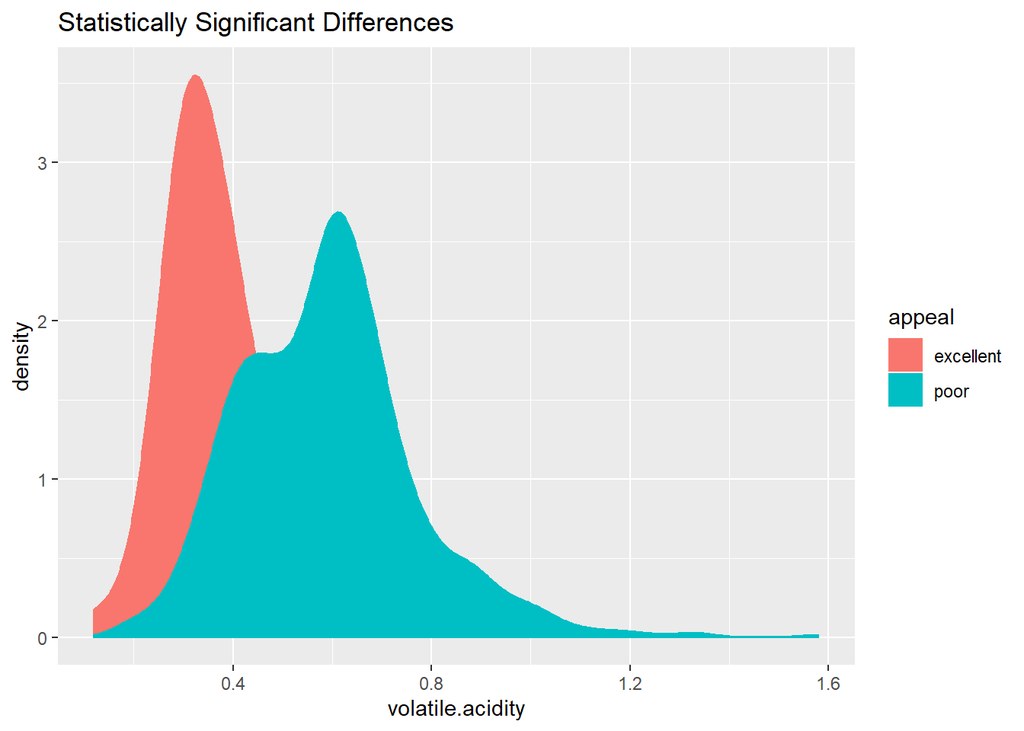

```r
ggplot(test_df,aes(x=volatile.acidity,color=appeal,fill=appeal)) +
  geom_density() +
  labs(title="Statistically Significant Differences")
```

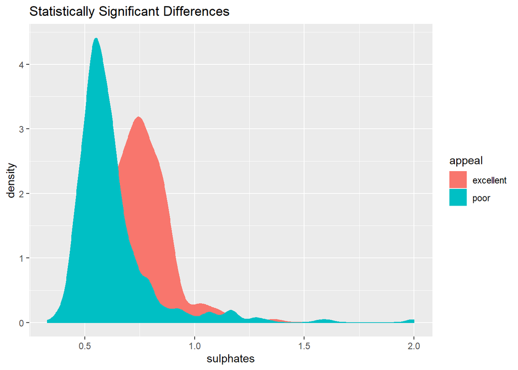

```r
ggplot(test_df,aes(x=sulphates,color=appeal,fill=appeal)) +
  geom_density() +
  labs(title="Statistically Significant Differences")
```

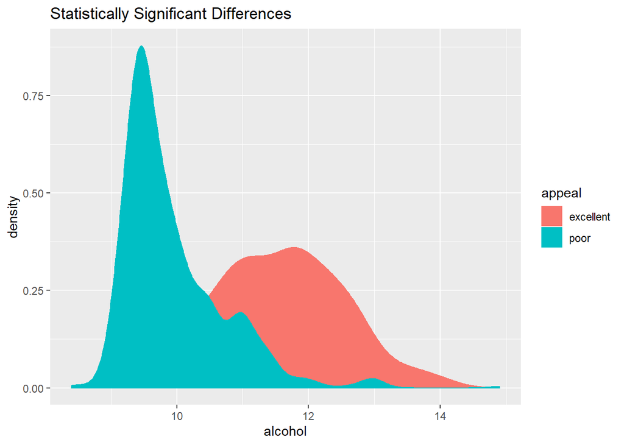

```r
ggplot(test_df,aes(x=alcohol,color=appeal,fill=appeal)) +
  geom_density() +
  labs(title="Statistically Significant Differences")
```

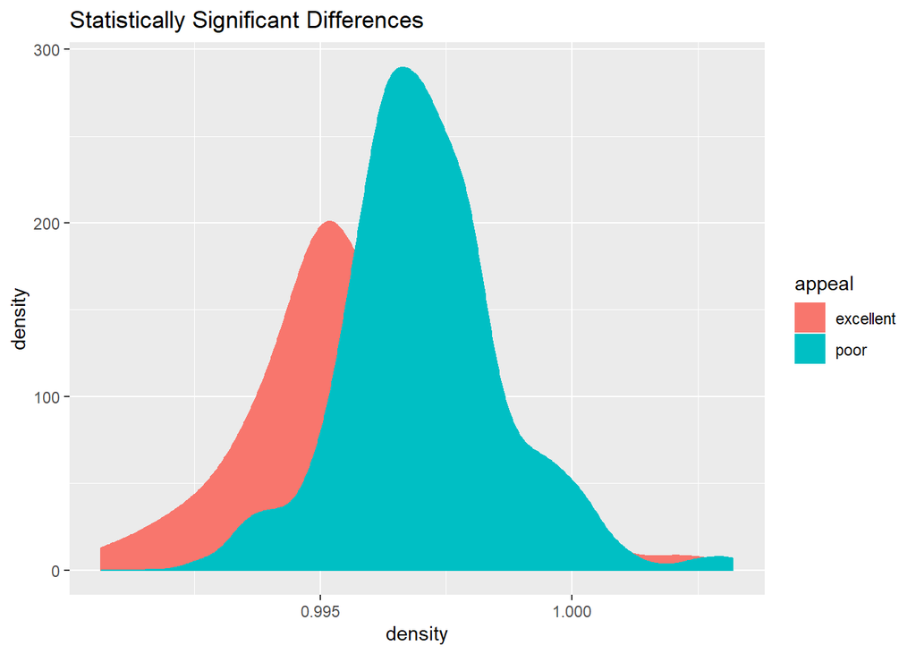

```r
ggplot(test_df,aes(x=density,color=appeal,fill=appeal)) +
  geom_density() +
  labs(title="Statistically Significant Differences")
```

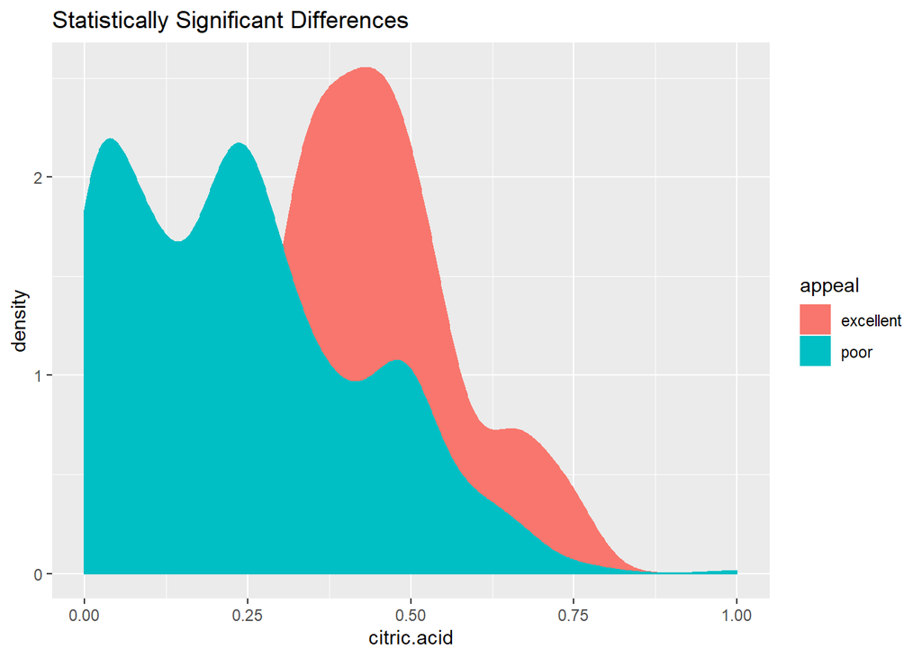

```r
ggplot(test_df,aes(x=citric.acid,color=appeal,fill=appeal)) +
  geom_density() +
  labs(title="Statistically Significant Differences")
```

## Question Four and the Chi-Square test.

We have been working with a data set of Protuguese red wine attributes and quality. There is also a very similar data set for Portuguese white wine. For this section we are going to read the white wine data and compare it with the red wine.

Question Four: Do peoples’ red wine quality ratings differ significantly from their white wine ratings, according to the Chi-Square test?

Assumptions: We have two random independent samples of frequency counts (red wind and white wine quality ratings). The samples are separate and mutually exclusive. (There are no rose wines.) At least eighty-percent of the populated cells have five or more counts. R’s simulate.p.value=TRUE adjustment is used since there are zero value cells.

H<sub>A</sub>: Red and white Portuguese wines are indistinguishable as far as rated quality.

```r
#  Let's see if people's views on the quality of red wine differ from
#  how their ratings are distributed amongst the white wines of Portugal.
#
wwine_df = read.csv("winequality-white.csv",header=TRUE,sep=";")

white = c(0,0,0,0,0,0,0,0,0,0)
white[1] = sum((wwine_df$quality==1))
white[2] = sum((wwine_df$quality==2))
white[3] = sum((wwine_df$quality==3))
white[4] = sum((wwine_df$quality==4))
white[5] = sum((wwine_df$quality==5))
white[6] = sum((wwine_df$quality==6))
white[7] = sum((wwine_df$quality==7))
white[8] = sum((wwine_df$quality==8))
white[9] = sum((wwine_df$quality==9))
white[10] = sum((wwine_df$quality==10))

chisq.test(x=red,y=white)
```

```
##
##  Pearson's Chi-squared test
##
## data:  red and white
## X-squared = 60, df = 42, p-value = 0.03528
```

```r
chisq.test(x=red,y=white,simulate.p.value = TRUE)
```

```
##
##  Pearson's Chi-squared test with simulated p-value (based on 2000
##  replicates)
##
## data:  red and white
## X-squared = 60, df = NA, p-value = 0.03848
```

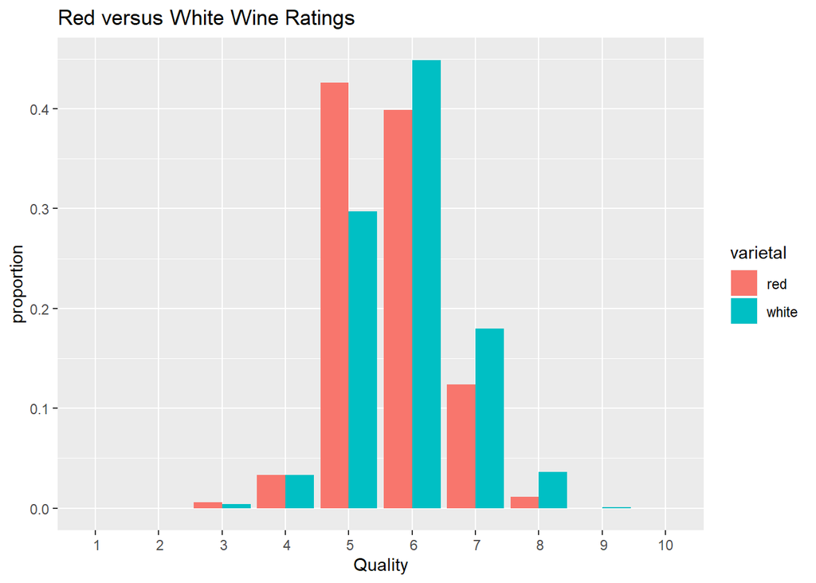

```r
sw = sum(white)

white[1] = round(white[1] / sw, 3)
white[2] = round(white[2] / sw, 3)
white[3] = round(white[3] / sw, 3)
white[4] = round(white[4] / sw, 3)
white[5] = round(white[5] / sw, 3)
white[6] = round(white[6] / sw, 3)
white[7] = round(white[7] / sw, 3)
white[8] = round(white[8] / sw, 3)
white[9] = round(white[9] / sw, 3)
white[10] = round(white[10] / sw, 3)

rw = sum(red)

red[1] = round(red[1] / rw, 3)
red[2] = round(red[2] / rw, 3)
red[3] = round(red[3] / rw, 3)
red[4] = round(red[4] / rw, 3)
red[5] = round(red[5] / rw, 3)
red[6] = round(red[6] / rw, 3)
red[7] = round(red[7] / rw, 3)
red[8] = round(red[8] / rw, 3)
red[9] = round(red[9] / rw, 3)
red[10] = round(red[10] / rw, 3)

red_white_quality_df =
    rbind(  data.frame(Quality=c(' 1',' 2',' 3',' 4',' 5',' 6',' 7',' 8',' 9','10'),
                       proportion=red,varietal='red'),
            data.frame(Quality=c(' 1',' 2',' 3',' 4',' 5',' 6',' 7',' 8',' 9','10'),
                       proportion=white,varietal='white'))

ggplot(data=red_white_quality_df) +
  geom_col(mapping=aes(x=Quality,y=proportion,fill=varietal),position="dodge") +
  labs(title="Red versus White Wine Ratings")
```

If you need red wine and all you have is white, is it alright to put some red food coloring in the white wine? This chi-squared test may not have measured all the factors involved, but it does raise an interesting question with regard to the quality profile of the two categories.

## Question Five - Linear Regression

Qyestion Five: Which attributes are associated with improved wine quality?

# H<sub>o</sub>: Volitile acidity is the same for excellent and other wines.

# H<sub>A</sub>: Low levels of volatile acidity are associated with excellent wines.

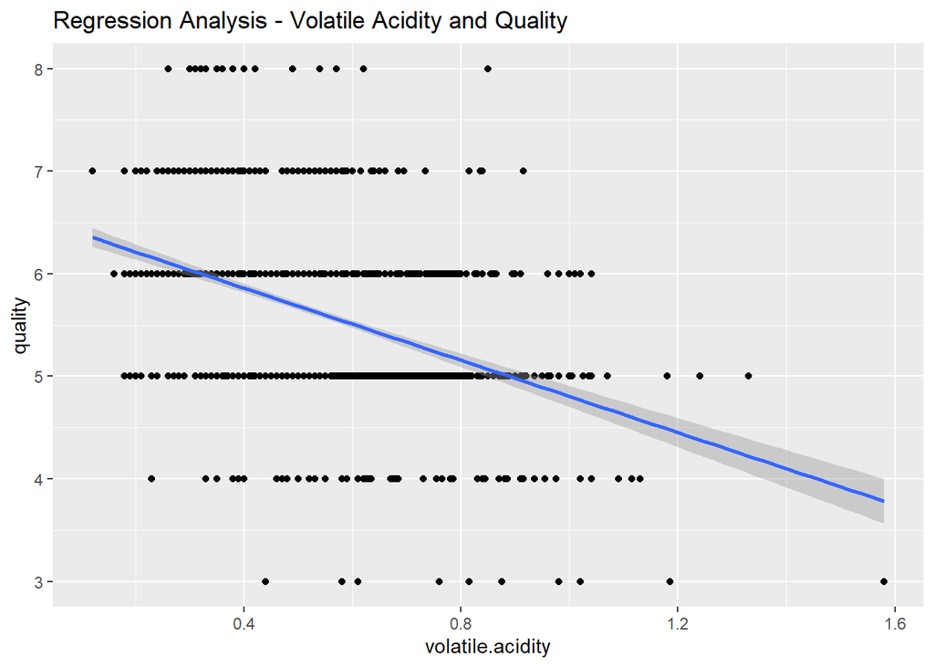

```r
ggplot(data=wine_df,mapping=aes(volatile.acidity,quality)) +
  geom_point() +
  geom_smooth(method="lm") +
   labs(title="Regression Analysis - Volatile Acidity and Quality")
```

```r
volatile_model = lm(quality~volatile.acidity,wine_df)
summary(volatile_model)
```

```
##
## Call:
## lm(formula = quality ~ volatile.acidity, data = wine_df)
##
## Residuals:
##      Min       1Q   Median       3Q      Max
## -2.79071 -0.54411 -0.00687  0.47350  2.93148
##
## Coefficients:
##                  Estimate Std. Error t value Pr(>|t|)
## (Intercept)       6.56575    0.05791  113.39   <2e-16 ***
## volatile.acidity -1.76144    0.10389  -16.95   <2e-16 ***
## ---
## Signif. codes:  0 '***' 0.001 '**' 0.01 '*' 0.05 '.' 0.1 ' ' 1
##
## Residual standard error: 0.7437 on 1597 degrees of freedom
## Multiple R-squared:  0.1525, Adjusted R-squared:  0.152
## F-statistic: 287.4 on 1 and 1597 DF,  p-value: < 2.2e-16
```

The slope is -1.76. The intercept is 6.566. The linear model is:

quality = -1.76 * volatile.acidity + 6.566

The p-values are very small for all variables. The model is statistically significant at the .05 level, the .01 level and below. Clearly volatile.acidity is negatively correlated with wine quality.

The correlation coefficient is -.39 which is fairly strong given the number of other factors we are measuring which impact the quality. The r-squared value is .1525 implying that it influences about fifteen percent of quality rating.

### Let’s try another one - Alcohol

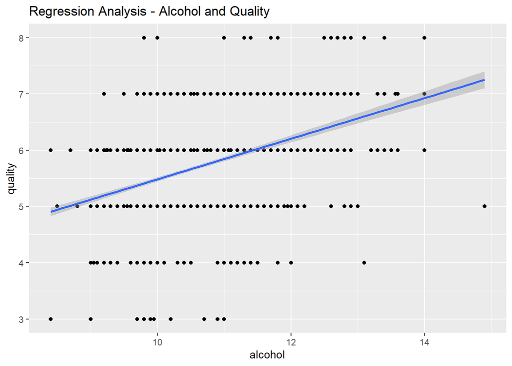

```r
ggplot(data=wine_df,mapping=aes(alcohol,quality)) +
  geom_point() +
  geom_smooth(method="lm") +
  labs(title="Regression Analysis - Alcohol and Quality")
```

```r
alcohol_model = lm(quality~alcohol,wine_df)
summary(alcohol_model)
```

```
##
## Call:
## lm(formula = quality ~ alcohol, data = wine_df)
##
## Residuals:
##     Min      1Q  Median      3Q     Max
## -2.8442 -0.4112 -0.1690  0.5166  2.5888
##
## Coefficients:
##             Estimate Std. Error t value Pr(>|t|)
## (Intercept)  1.87497    0.17471   10.73   <2e-16 ***
## alcohol      0.36084    0.01668   21.64   <2e-16 ***
## ---
## Signif. codes:  0 '***' 0.001 '**' 0.01 '*' 0.05 '.' 0.1 ' ' 1
##
## Residual standard error: 0.7104 on 1597 degrees of freedom
## Multiple R-squared:  0.2267, Adjusted R-squared:  0.2263
## F-statistic: 468.3 on 1 and 1597 DF,  p-value: < 2.2e-16
```

```r
alcohol_model
```

```
##
## Call:
## lm(formula = quality ~ alcohol, data = wine_df)
##
## Coefficients:
## (Intercept)      alcohol
##      1.8750       0.3608
```

The slope is 0.361. The intercept is 1.875. The linear model is:

quality = 0.36 * alcohol + 1.875.

The p-values are very small for all variables. The model is statistically significant at the .05 level, the .01 level and below. Clearly alcohol is positively correlated with wine quality, probably because ripe, sweet grapes have more sugar to ferment into alcohol than inferior fruit.

The correlation coefficient is 0.476 which is fairly strong given the number of other factors we are measuring which impact the quality. The r-squared value is .227 implying that it influences about twenty-three percent of quality rating, even more than the volatile acid at fifteen percent.

### A few more r-squareds

```r
summary(lm(quality~sulphates,wine_df))
```

```
##
## Call:
## lm(formula = quality ~ sulphates, data = wine_df)
##
## Residuals:
##     Min      1Q  Median      3Q     Max
## -3.2432 -0.5424  0.1102  0.4456  2.3977
##
## Coefficients:
##             Estimate Std. Error t value Pr(>|t|)
## (Intercept)  4.84775    0.07842   61.82   <2e-16 ***
## sulphates    1.19771    0.11539   10.38   <2e-16 ***
## ---
## Signif. codes:  0 '***' 0.001 '**' 0.01 '*' 0.05 '.' 0.1 ' ' 1
##
## Residual standard error: 0.7819 on 1597 degrees of freedom
## Multiple R-squared:  0.0632, Adjusted R-squared:  0.06261
## F-statistic: 107.7 on 1 and 1597 DF,  p-value: < 2.2e-16
```

```r
summary(lm(quality~citric.acid,wine_df))
```

```
##
## Call:
## lm(formula = quality ~ citric.acid, data = wine_df)
##
## Residuals:
##     Min      1Q  Median      3Q     Max
## -3.0011 -0.5976  0.1021  0.5057  2.5901
##
## Coefficients:
##             Estimate Std. Error t value Pr(>|t|)
## (Intercept)  5.38172    0.03372 159.610   <2e-16 ***
## citric.acid  0.93845    0.10104   9.288   <2e-16 ***
## ---
## Signif. codes:  0 '***' 0.001 '**' 0.01 '*' 0.05 '.' 0.1 ' ' 1
##
## Residual standard error: 0.7869 on 1597 degrees of freedom
## Multiple R-squared:  0.05124,    Adjusted R-squared:  0.05065
## F-statistic: 86.26 on 1 and 1597 DF,  p-value: < 2.2e-16
```

```r
summary(lm(quality~density,wine_df))
```

```
##
## Call:
## lm(formula = quality ~ density, data = wine_df)
##
## Residuals:
##     Min      1Q  Median      3Q     Max
## -2.7885 -0.6216  0.1554  0.4271  2.5177
##
## Coefficients:
##             Estimate Std. Error t value Pr(>|t|)
## (Intercept)    80.24      10.51   7.636 3.83e-14 ***
## density       -74.85      10.54  -7.100 1.87e-12 ***
## ---
## Signif. codes:  0 '***' 0.001 '**' 0.01 '*' 0.05 '.' 0.1 ' ' 1
##
## Residual standard error: 0.7954 on 1597 degrees of freedom
## Multiple R-squared:  0.0306, Adjusted R-squared:  0.02999
## F-statistic: 50.41 on 1 and 1597 DF,  p-value: 1.875e-12
```

The above three factors have a combined r-squared of about fourteen, which combined with volatile acid and alcohol above account for about half the quality ratings.

## Ethics

This doesn’t bring to mind the questions of abusive human experimentation or malpractice one might encounter in the study of drugs or medical procedures.

We do have the question of romanticising alcohol use. When it turned out that the phisiochemical factor with the strongest positive correlation to perceived wine quality was alcohol content, it surprised me. I expect it speaks to the quality of grapes more than a quest for inebriation, but still…

I was hoping to bring samples to class, but I guess I can’t do that anymore;)